# tarefaDryBean

2022-09-10

### 1.Carregue a base de dados e mostre a estrutura do dataset (str()). Comente sobre o número de amostras, de variáveis (e seu tipo). O arquivo do dataset não pode ser modificado de forma alguma. A leitura deverá ser realizada de tal maneira qualquer característica dos dados.

```r
setwd("C:\\Users\\Mauricio\\Desktop\\Material\\Atividades\\Computação aplicada")

dados = read.csv("Dry_Bean_Dataset.csv",sep=";",dec=",")
```

```r
str(dados)
```

```
## 'data.frame':    13611 obs. of  17 variables:
##  $ Area           : int  28395 28734 29380 30008 30140 30279 30477 30519 30685 30834 ...
##  $ Perimeter      : num  610 638 624 646 620 ...
##  $ MajorAxisLength: num  208 201 213 211 202 ...
##  $ MinorAxisLength: num  174 183 176 183 190 ...
##  $ AspectRation   : num  1.2 1.1 1.21 1.15 1.06 ...
##  $ Eccentricity   : num  0.55 0.412 0.563 0.499 0.334 ...
##  $ ConvexArea     : int  28715 29172 29690 30724 30417 30600 30970 30847 31044 31120 ...
##  $ EquivDiameter  : num  190 191 193 195 196 ...
##  $ Extent         : num  0.764 0.784 0.778 0.783 0.773 ...
##  $ Solidity       : num  0.989 0.985 0.99 0.977 0.991 ...
##  $ roundness      : num  0.958 0.887 0.948 0.904 0.985 ...
##  $ Compactness    : num  0.913 0.954 0.909 0.928 0.971 ...
##  $ ShapeFactor1   : num  0.00733 0.00698 0.00724 0.00702 0.0067 ...
##  $ ShapeFactor2   : num  0.00315 0.00356 0.00305 0.00321 0.00366 ...
##  $ ShapeFactor3   : num  0.834 0.91 0.826 0.862 0.942 ...
##  $ ShapeFactor4   : num  0.999 0.998 0.999 0.994 0.999 ...
##  $ Class          : chr  "SEKER" "SEKER" "SEKER" "SEKER" ...
```

```r
##Para obter os nomes das colunas, deve-se utilizar a funÃ§Ã£o names()
names(dados)
```

```
##  [1] "Area"            "Perimeter"       "MajorAxisLength" "MinorAxisLength"
##  [5] "AspectRation"    "Eccentricity"    "ConvexArea"      "EquivDiameter"
##  [9] "Extent"          "Solidity"        "roundness"       "Compactness"
## [13] "ShapeFactor1"    "ShapeFactor2"    "ShapeFactor3"    "ShapeFactor4"
## [17] "Class"
```

```r
#InformaÃ§Ãµes acerca das dimensÃµes da estrutura
ncol(dados)
```

```
## [1] 17
```

```r
nrow(dados)
```

```
## [1] 13611
```

```r
dim(dados)
```

```
## [1] 13611    17
```

```r
for (i in 1:17) {
  print(dados[0,i])
}
```

```
## integer(0)
## numeric(0)
## numeric(0)
## numeric(0)
## numeric(0)
## numeric(0)
## integer(0)
## numeric(0)
## numeric(0)
## numeric(0)
## numeric(0)
## numeric(0)
## numeric(0)
## numeric(0)
## numeric(0)
## numeric(0)
## character(0)
```

### 2.Altere a variável do tipo do feijão (Class) para um factor. Utilizando um comando mostre como estimar o número de classes existentes.

```r
#print(dados$Class)
dados$Class = factor(c(dados$Class))
summary(dados$Class)
```

```
## BARBUNYA   BOMBAY     CALI DERMASON    HOROZ    SEKER     SIRA
##     1322      522     1630     3546     1928     2027     2636
```

```r
length(summary(dados$Class))
```

```
## [1] 7
```

### 3.Quantas amostras existem por classe? Use um gráfico de barras para ilustrar as quantidades.

```r
summary(dados$Class)
```

```
## BARBUNYA   BOMBAY     CALI DERMASON    HOROZ    SEKER     SIRA
##     1322      522     1630     3546     1928     2027     2636
```

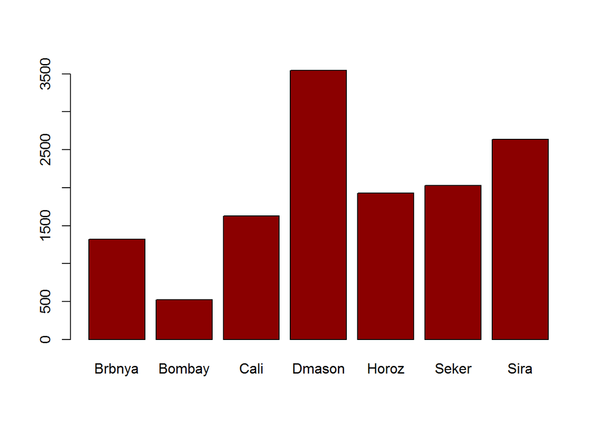

```r
barplot(summary(dados$Class),names.arg = c("Brbnya", "Bombay", "Cali", "Dmason", "Horoz", "Seker", "Sira"),col="darkred")
```

```r
#View(dados)
#boxplot(summary(dados$Class))
```

## 4.Alguma variável apresenta outliers? Tem alguma que não apresenta? Se as amostras com outliers fossem removidas, reduziria em quanto o número de amostras? Alguma classe sofreria uma redução maior do que a outra? Crie um boxplot por variável (boxplot()) para auxiliar na explicação. Não remova os outliers para as próximas etapas!

### Resposta: Sim todas possuem outliers exceto as variaveis ShapeFactor2 e Class.

```r
#boxplot com todas variaveis
# boxplot(dados$Area)
# boxplot(dados$Perimeter)
# boxplot(dados$MajorAxisLength)
# boxplot(dados$MinorAxisLength)
# boxplot(dados$AspectRation)
# boxplot(dados$Eccentricity)
# boxplot(dados$ConvexArea)
# boxplot(dados$EquivDiameter)
# boxplot(dados$Extent)
# boxplot(dados$Solidity)
# boxplot(dados$roundness)
# boxplot(dados$Compactness)
# boxplot(dados$ShapeFactor1)
# boxplot(dados$ShapeFactor2)
# boxplot(dados$ShapeFactor3)
# boxplot(dados$ShapeFactor4)
# boxplot(dados$Class)
```

```r
for (i in 1:17) {
print(colnames(dados[i]))

}
```

```
## [1] "Area"
## [1] "Perimeter"
## [1] "MajorAxisLength"
## [1] "MinorAxisLength"
## [1] "AspectRation"
## [1] "Eccentricity"
## [1] "ConvexArea"
## [1] "EquivDiameter"
## [1] "Extent"
## [1] "Solidity"
## [1] "roundness"
## [1] "Compactness"
## [1] "ShapeFactor1"
## [1] "ShapeFactor2"
## [1] "ShapeFactor3"
## [1] "ShapeFactor4"
## [1] "Class"
```

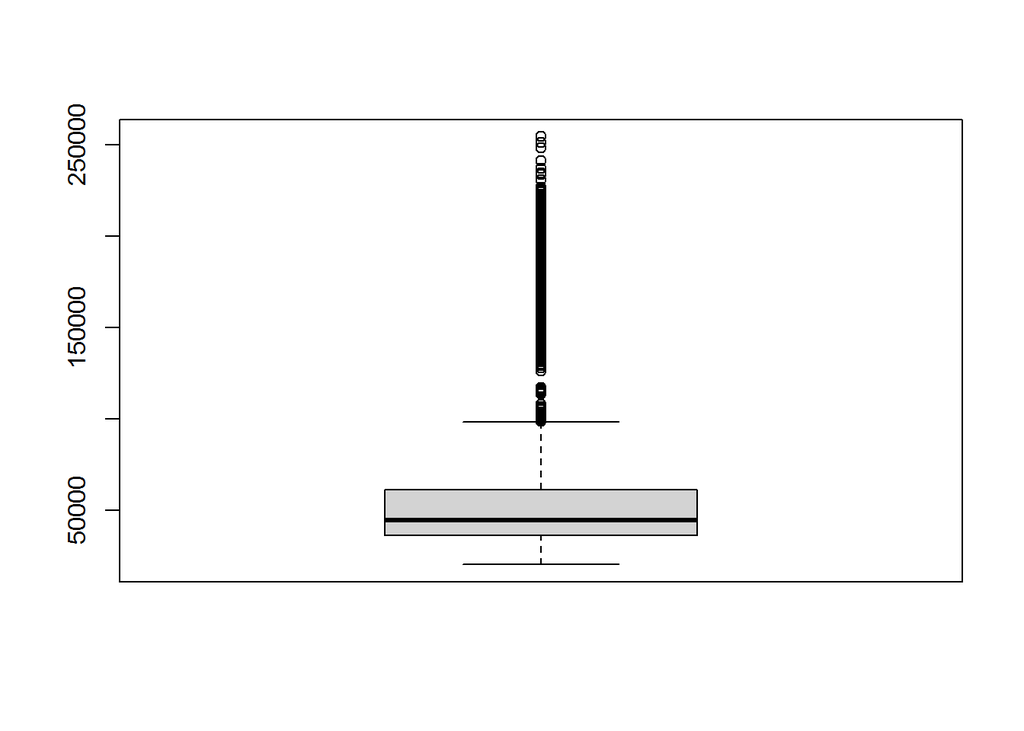

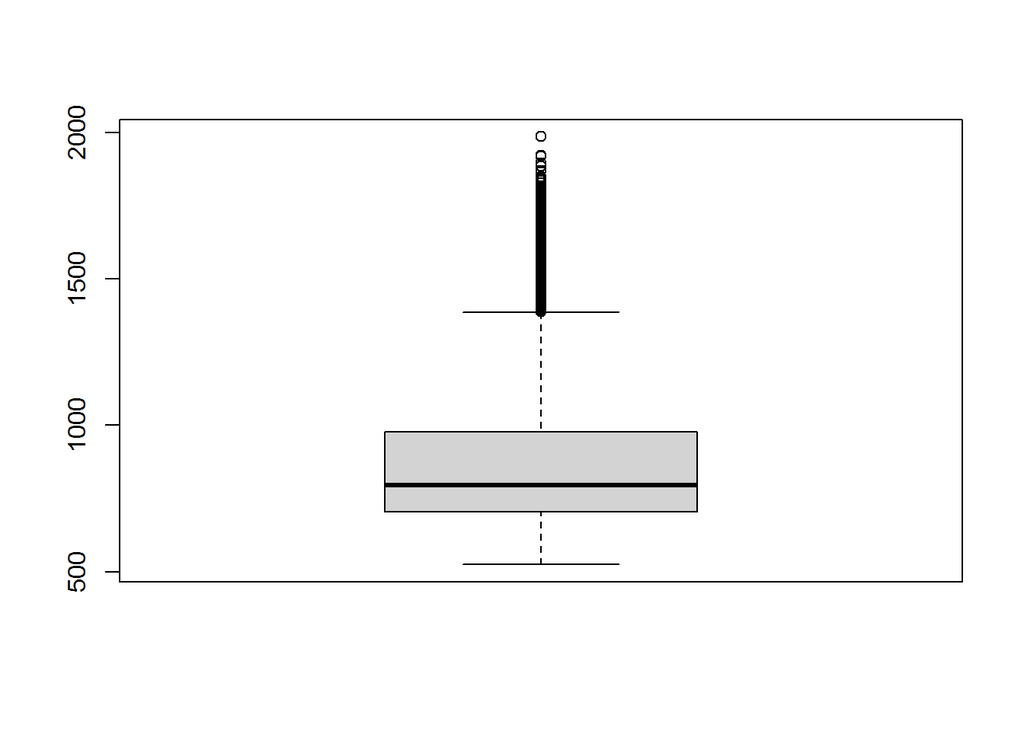

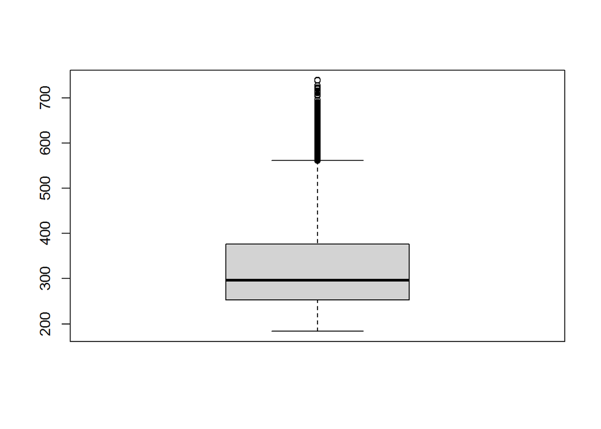

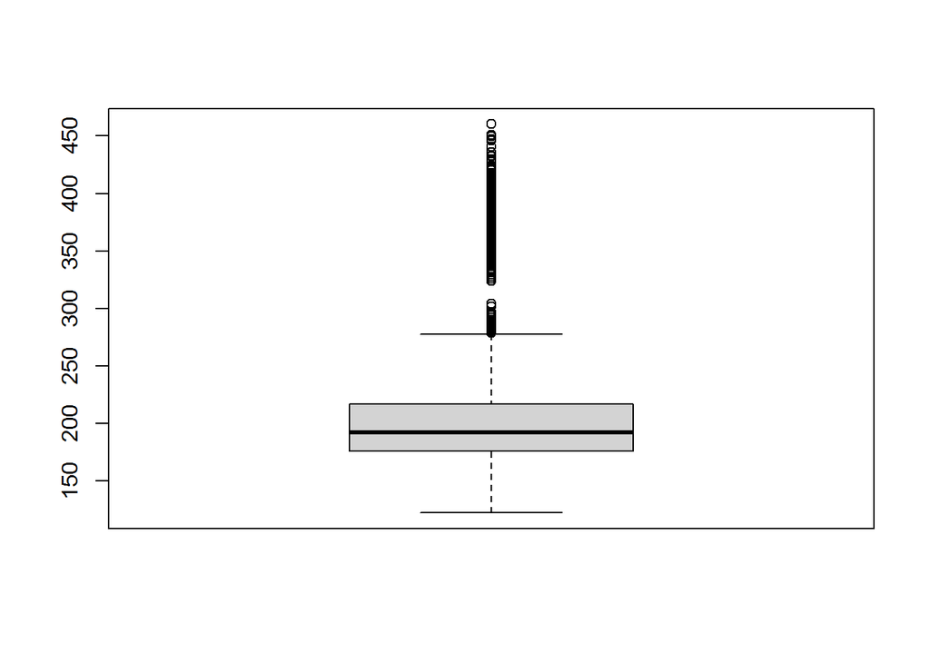

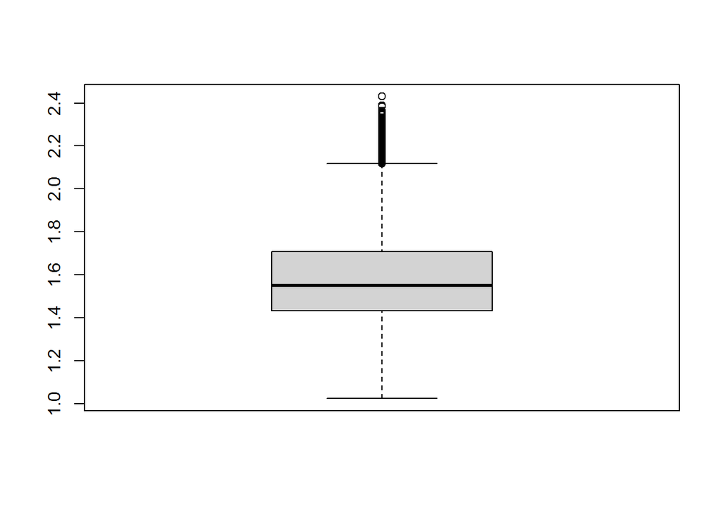

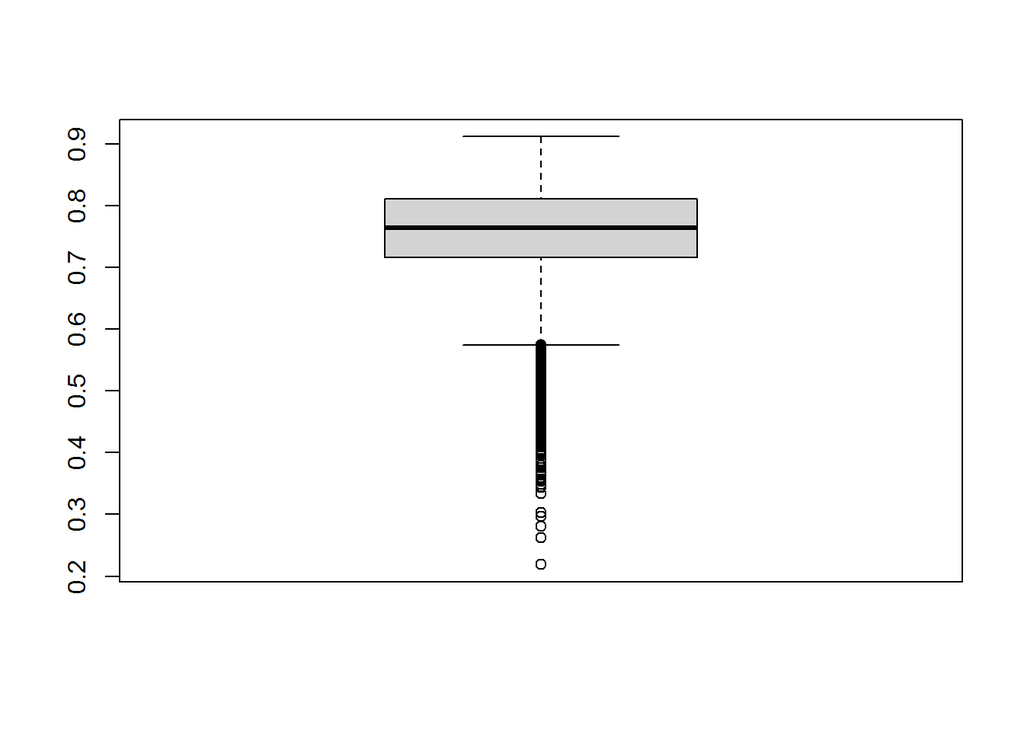

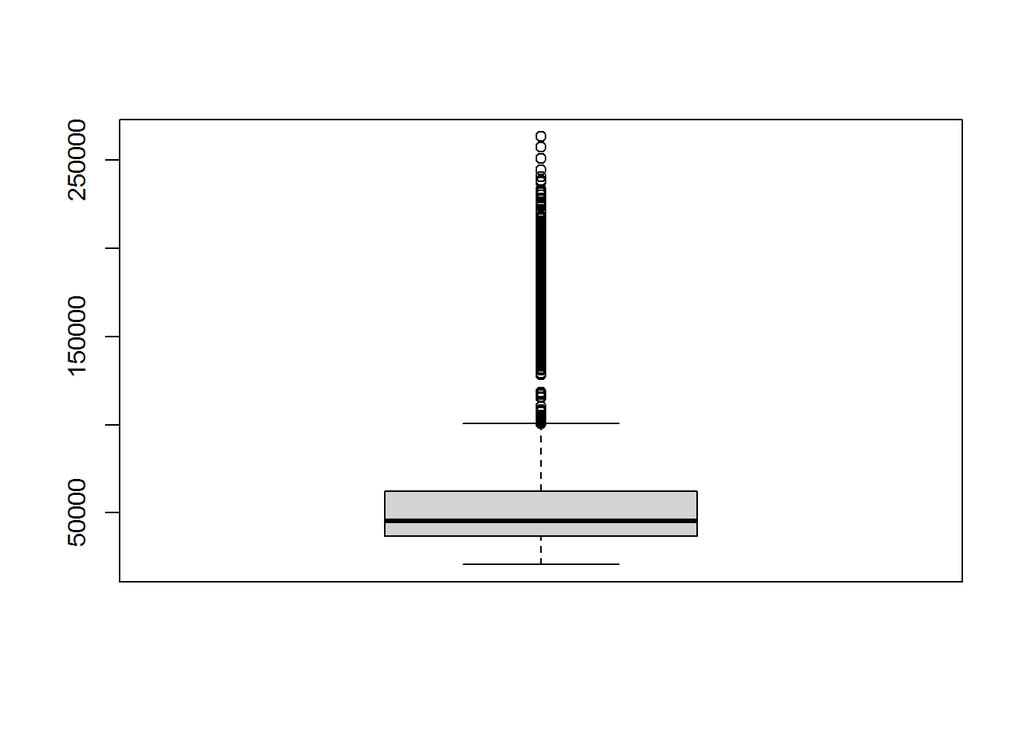

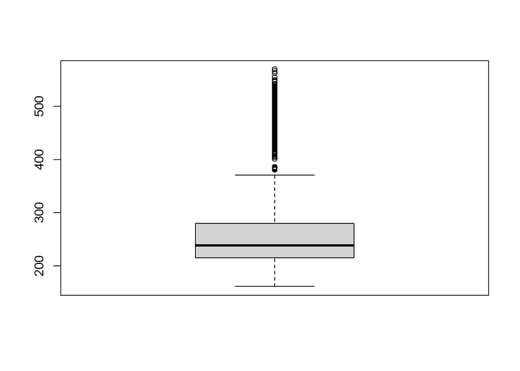

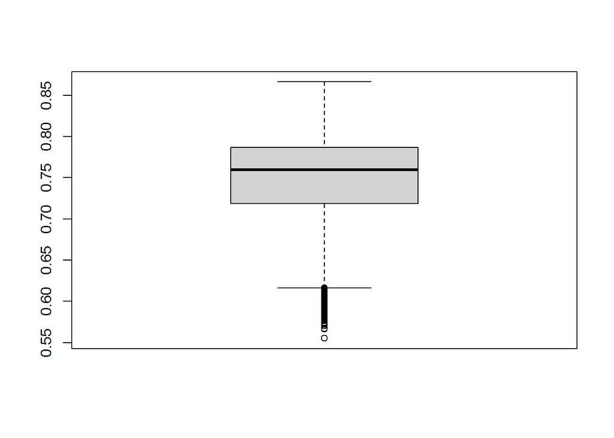

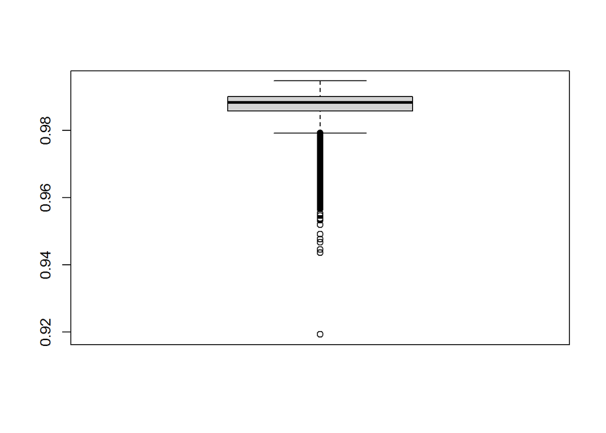

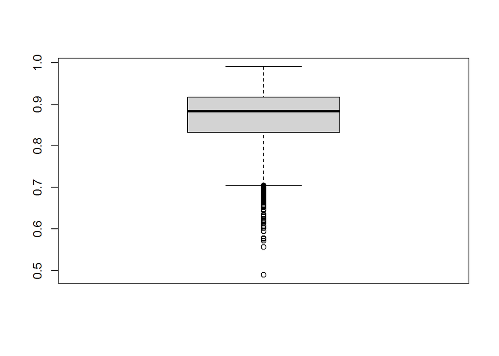

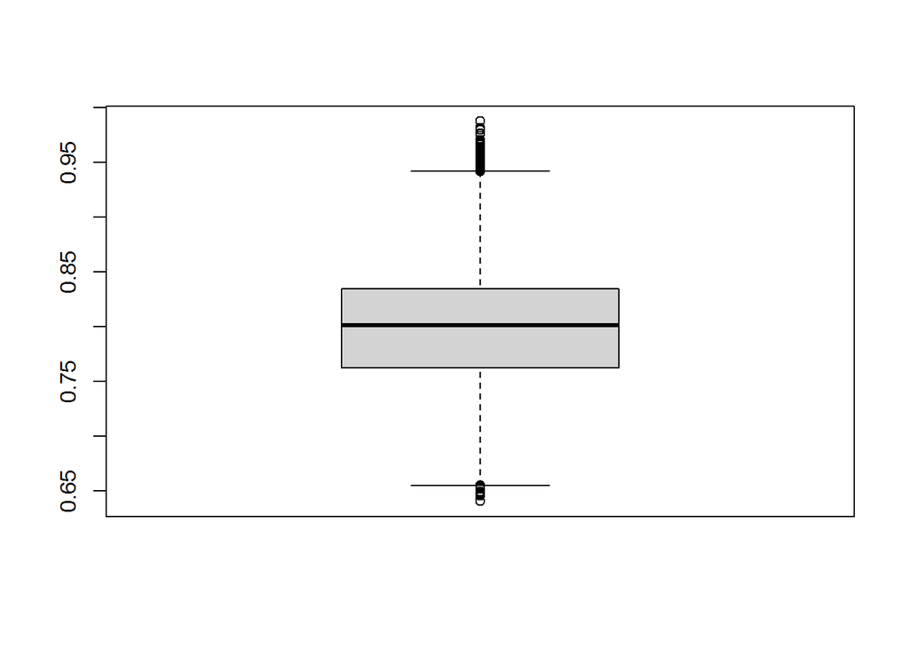

[5 more figures not shown]

```r
for (i in 1:17) {
boxplot(dados[,colnames(dados[i])])

}
```

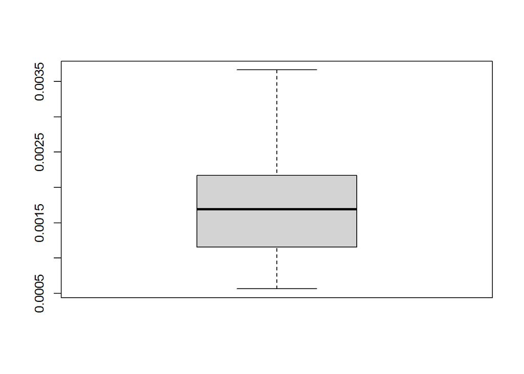

```r
#variaveis sem outliers
boxplot(dados$ShapeFactor2)
```

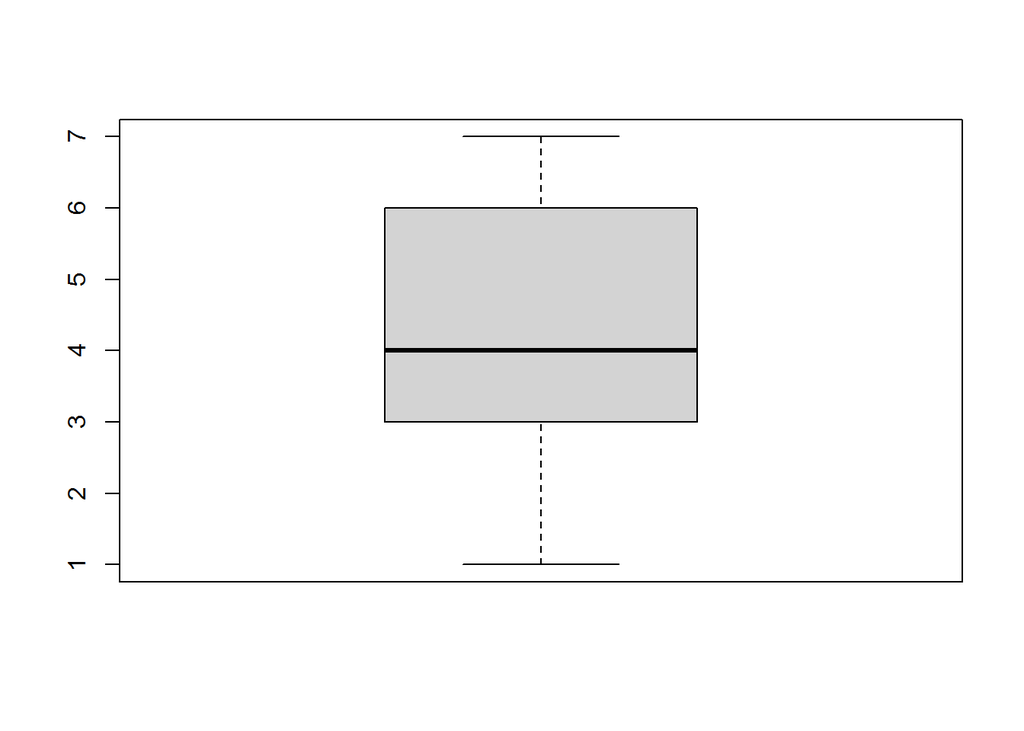

```r
boxplot(dados$Class)
```

### outliers variavel Area

```r
outliers=which(dados$Area %in% boxplot.stats(dados$Area)$out)
print(paste("Total de outliers eh ",length(outliers)))
```

```
## [1] "Total de outliers eh  551"
```

```r
print(paste("Sem os outliers ficaria com ",length(dados$Area)-length(outliers)))
```

```
## [1] "Sem os outliers ficaria com  13060"
```

```r
#print(outliers)
```

### outliers da variavel Perimeter

```r
outliers=which(dados$Perimeter %in% boxplot.stats(dados$Perimeter)$out)
print(paste("Total de outliers eh ",length(outliers)))
```

```
## [1] "Total de outliers eh  500"
```

```r
print(paste("Sem os outliers ficaria com ",length(dados$Perimeter)-length(outliers)))
```

```
## [1] "Sem os outliers ficaria com  13111"
```

```r
#print(outliers)
```

### outliers da variavel MajorAxisLength

```r
outliers=which(dados$MajorAxisLength %in% boxplot.stats(dados$MajorAxisLength)$out)
print(paste("Total de outliers eh ",length(outliers)))
```

```
## [1] "Total de outliers eh  379"
```

```r
print(paste("Sem os outliers ficaria com ",length(dados$MajorAxisLength)-length(outliers)))
```

```
## [1] "Sem os outliers ficaria com  13232"
```

```r
#print(outliers)
```

### outliers da variavel MinorAxisLength

```r
outliers=which(dados$MinorAxisLength %in% boxplot.stats(dados$MinorAxisLength)$out)
print(paste("Total de outliers eh ",length(outliers)))
```

```
## [1] "Total de outliers eh  569"
```

```r
print(paste("Sem os outliers ficaria com ",length(dados$MinorAxisLength)-length(outliers)))
```

```
## [1] "Sem os outliers ficaria com  13042"
```

```r
#print(outliers)
```

### outliers da variavel AspectRation

```r
outliers=which(dados$AspectRation %in% boxplot.stats(dados$AspectRation)$out)
print(paste("Total de outliers eh ",length(outliers)))
```

```
## [1] "Total de outliers eh  473"
```

```r
print(paste("Sem os outliers ficaria com ",length(dados$AspectRation)-length(outliers)))
```

```
## [1] "Sem os outliers ficaria com  13138"
```

```r
#print(outliers)
```

### outliers da variavel Eccentricity

```r
outliers=which(dados$Eccentricity %in% boxplot.stats(dados$Eccentricity)$out)
print(paste("Total de outliers eh ",length(outliers)))
```

```
## [1] "Total de outliers eh  843"
```

```r
print(paste("Sem os outliers ficaria com ",length(dados$Eccentricity)-length(outliers)))
```

```
## [1] "Sem os outliers ficaria com  12768"
```

```r
#print(outliers)
```

### outliers da variavel ConvexArea

```r
outliers=which(dados$ConvexArea %in% boxplot.stats(dados$ConvexArea)$out)
print(paste("Total de outliers eh ",length(outliers)))
```

```
## [1] "Total de outliers eh  550"
```

```r
print(paste("Sem os outliers ficaria com ",length(dados$ConvexArea)-length(outliers)))
```

```
## [1] "Sem os outliers ficaria com  13061"
```

```r
#print(outliers)
```

### outliers da variavel EquivDiameter

```r
outliers=which(dados$EquivDiameter %in% boxplot.stats(dados$EquivDiameter)$out)
print(paste("Total de outliers eh ",length(outliers)))
```

```
## [1] "Total de outliers eh  526"
```

```r
print(paste("Sem os outliers ficaria com ",length(dados$EquivDiameter)-length(outliers)))
```

```
## [1] "Sem os outliers ficaria com  13085"
```

```r
#print(outliers)
```

### outliers da variavel Extent

```r
outliers=which(dados$Extent %in% boxplot.stats(dados$Extent)$out)
print(paste("Total de outliers eh ",length(outliers)))
```

```
## [1] "Total de outliers eh  275"
```

```r
print(paste("Sem os outliers ficaria com ",length(dados$Extent)-length(outliers)))
```

```
## [1] "Sem os outliers ficaria com  13336"
```

```r
#print(outliers)
```

### outliers da variavel Solidity

```r
outliers=which(dados$Solidity %in% boxplot.stats(dados$Solidity)$out)
print(paste("Total de outliers eh ",length(outliers)))
```

```
## [1] "Total de outliers eh  778"
```

```r
print(paste("Sem os outliers ficaria com ",length(dados$Solidity)-length(outliers)))
```

```
## [1] "Sem os outliers ficaria com  12833"
```

```r
#print(outliers)
```

### outliers da variavel roundness

```r
outliers=which(dados$roundness %in% boxplot.stats(dados$roundness)$out)
print(paste("Total de outliers eh ",length(outliers)))
```

```
## [1] "Total de outliers eh  91"
```

```r
print(paste("Sem os outliers ficaria com ",length(dados$roundness)-length(outliers)))
```

```
## [1] "Sem os outliers ficaria com  13520"
```

```r
#print(outliers)
```

### outliers da variavel Compactness

```r
outliers=which(dados$Compactness %in% boxplot.stats(dados$Compactness)$out)
print(paste("Total de outliers eh ",length(outliers)))
```

```
## [1] "Total de outliers eh  109"
```

```r
print(paste("Sem os outliers ficaria com ",length(dados$Compactness)-length(outliers)))
```

```
## [1] "Sem os outliers ficaria com  13502"
```

```r
#print(outliers)
```

### outliers da variavel ShapeFactor1

```r
outliers=which(dados$ShapeFactor1 %in% boxplot.stats(dados$ShapeFactor1)$out)
print(paste("Total de outliers eh ",length(outliers)))
```

```
## [1] "Total de outliers eh  533"
```

```r
print(paste("Sem os outliers ficaria com ",length(dados$ShapeFactor1)-length(outliers)))
```

```
## [1] "Sem os outliers ficaria com  13078"
```

```r
#print(outliers)
```

### outliers da variavel ShapeFactor2

```r
outliers=which(dados$ShapeFactor2 %in% boxplot.stats(dados$ShapeFactor2)$out)
print(paste("Total de outliers eh ",length(outliers)))
```

```
## [1] "Total de outliers eh  0"
```

```r
print(paste("Sem os outliers ficaria com ",length(dados$ShapeFactor2)-length(outliers)))
```

```
## [1] "Sem os outliers ficaria com  13611"
```

```r
#print(outliers)
```

### outliers da variavel ShapeFactor3

```r
outliers=which(dados$ShapeFactor3 %in% boxplot.stats(dados$ShapeFactor3)$out)
print(paste("Total de outliers eh ",length(outliers)))
```

```
## [1] "Total de outliers eh  195"
```

```r
print(paste("Sem os outliers ficaria com ",length(dados$ShapeFactor3)-length(outliers)))
```

```
## [1] "Sem os outliers ficaria com  13416"
```

```r
#print(outliers)
```

### outliers da variavel ShapeFactor4

```r
outliers=which(dados$ShapeFactor4 %in% boxplot.stats(dados$ShapeFactor4)$out)
print(paste("Total de outliers eh ",length(outliers)))
```

```
## [1] "Total de outliers eh  767"
```

```r
print(paste("Sem os outliers ficaria com ",length(dados$ShapeFactor4)-length(outliers)))
```

```
## [1] "Sem os outliers ficaria com  12844"
```

```r
#print(outliers)
```

### outliers da variavel Class

```r
outliers=which(dados$Class %in% boxplot.stats(dados$Class)$out)
print(paste("Total de outliers eh ",length(outliers)))
```

```
## [1] "Total de outliers eh  0"
```

```r
print(paste("Sem os outliers ficaria com ",length(dados$Class)-length(outliers)))
```

```
## [1] "Sem os outliers ficaria com  13611"
```

```r
#print(outliers)
```

```r
print(levels(dados$Class))
```

```
## [1] "BARBUNYA" "BOMBAY"   "CALI"     "DERMASON" "HOROZ"    "SEKER"    "SIRA"
```

### 5. Utilizando um gráfico boxplot por variável x classe (organize em 3 colunas), diga qual é a variável que teria maior poder de discriminação? Justifique a sua escolha.

### Nas variaveis Area,Perimeter,MajorAxisLength,MinorAxisLength,ConvexArea,EquivDiameter,ShapeFactor1,ShapeFactor2 se destaca o feijão Bombay.

### Nas variavel AspectRation o maior poder de discriminação é no feijão Horoz. ### Nas variaveis Eccentricity,Solidity,roundness,Compactness,ShapeFactor3,ShapeFactor4 o maior poder de discriminação está no feijão Seker

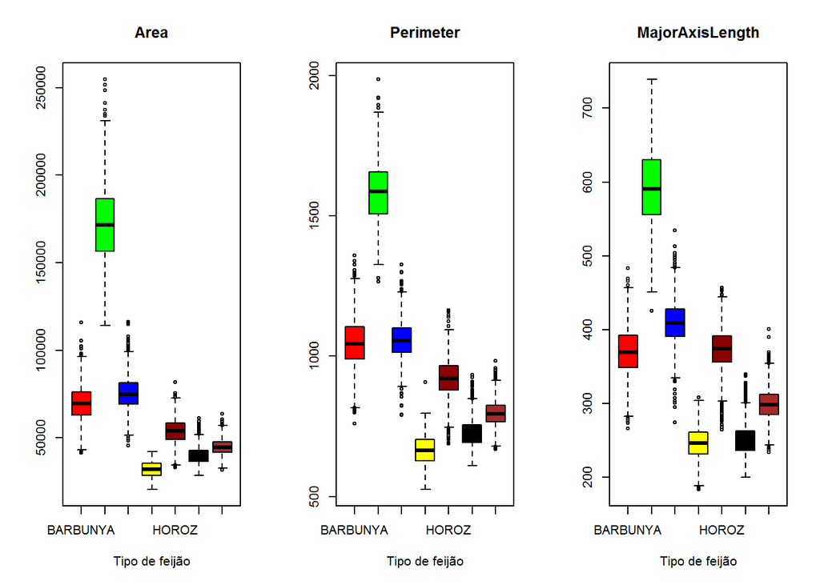

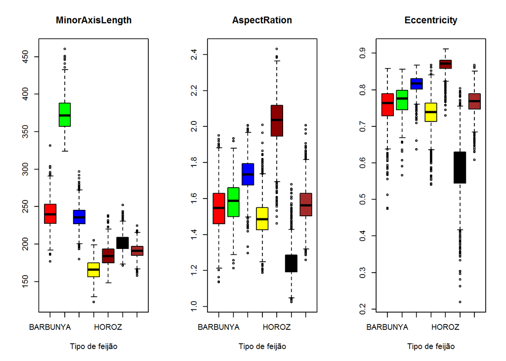

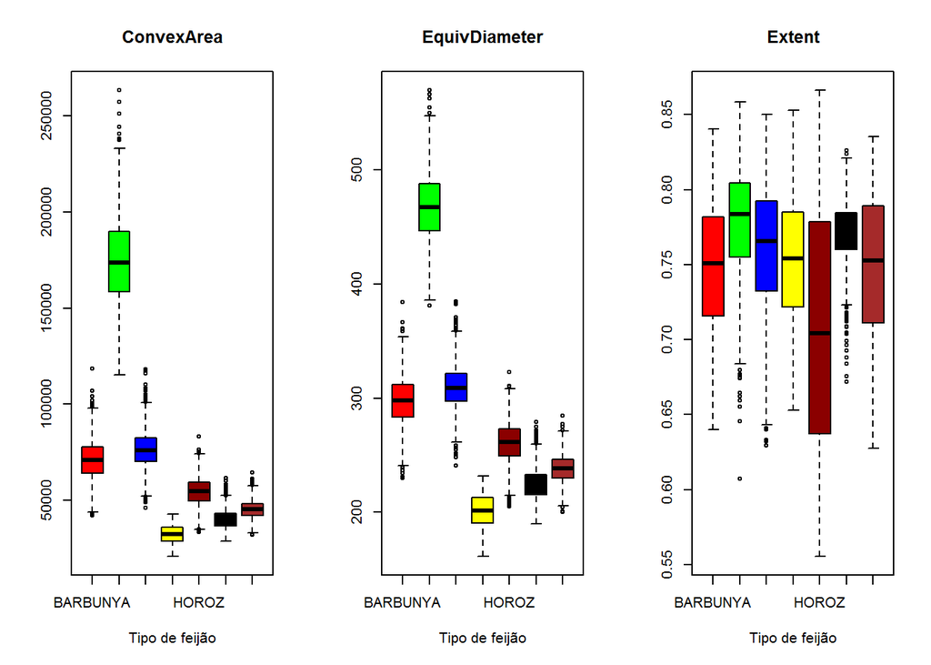

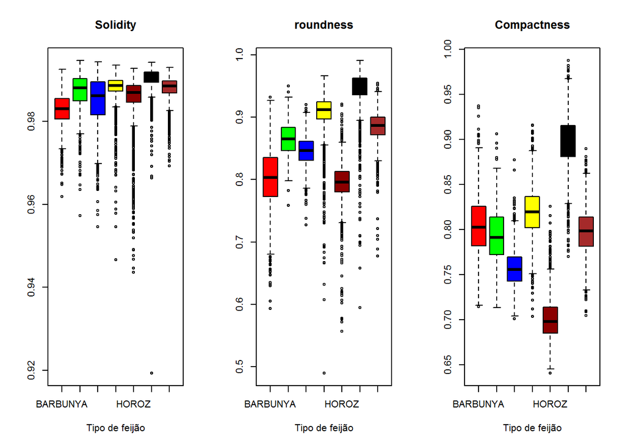

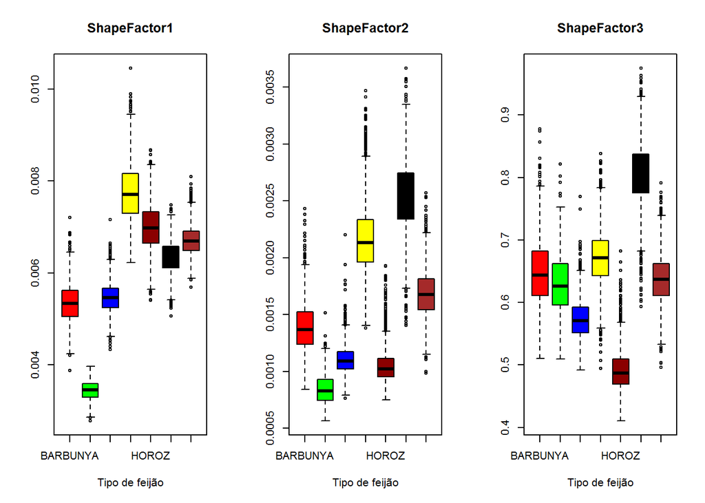

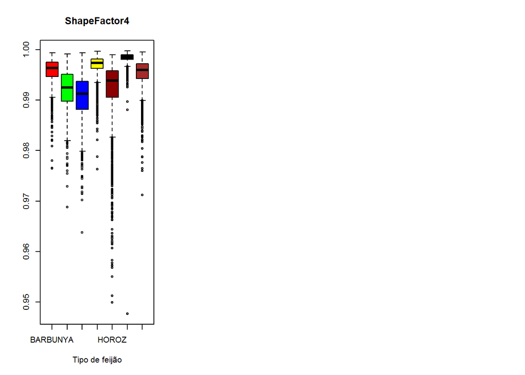

```r
cores = c("red","green","blue","yellow","darkred","black","brown")
par(mfrow=c(1,3))
for (i in 1:16) {
boxplot(dados[,i] ~ dados$Class, col=cores, xlab="Tipo de feijão",
ylab="", main=names(dados)[i])
}
```

### 6.Utilizando gráficos de densidade por variável (organize em 3 colunas), é possível fazer alguma afirmação sobre a discriminabilidade de alguma classe? Pode utilizar os boxplots gerados na etapa anterior para auxiliar nas conclusões.

```r
library(gridExtra)
library(ggplot2)
```

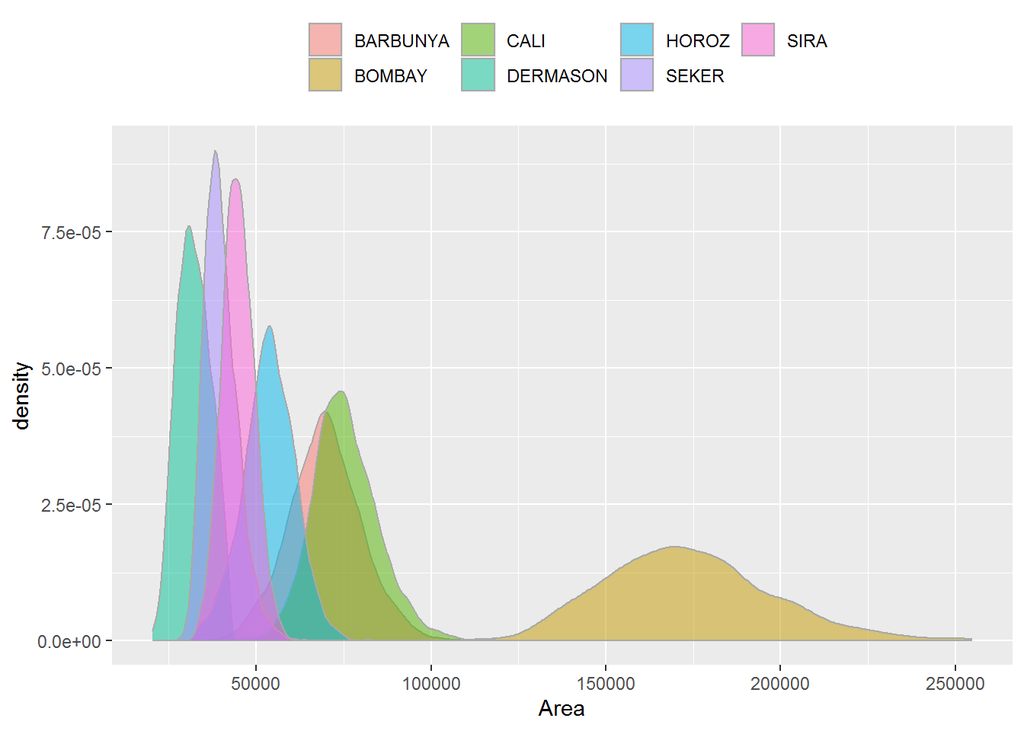

```r
p = list()
for(i in 1:1){
p[[i]] = ggplot(dados, aes_string(x=names(dados)[i],fill="Class")) +
geom_density(alpha=0.5,color="darkgray") +
theme(legend.position="top", legend.title = element_blank())
}
do.call(grid.arrange,c(p,ncol=1))
```

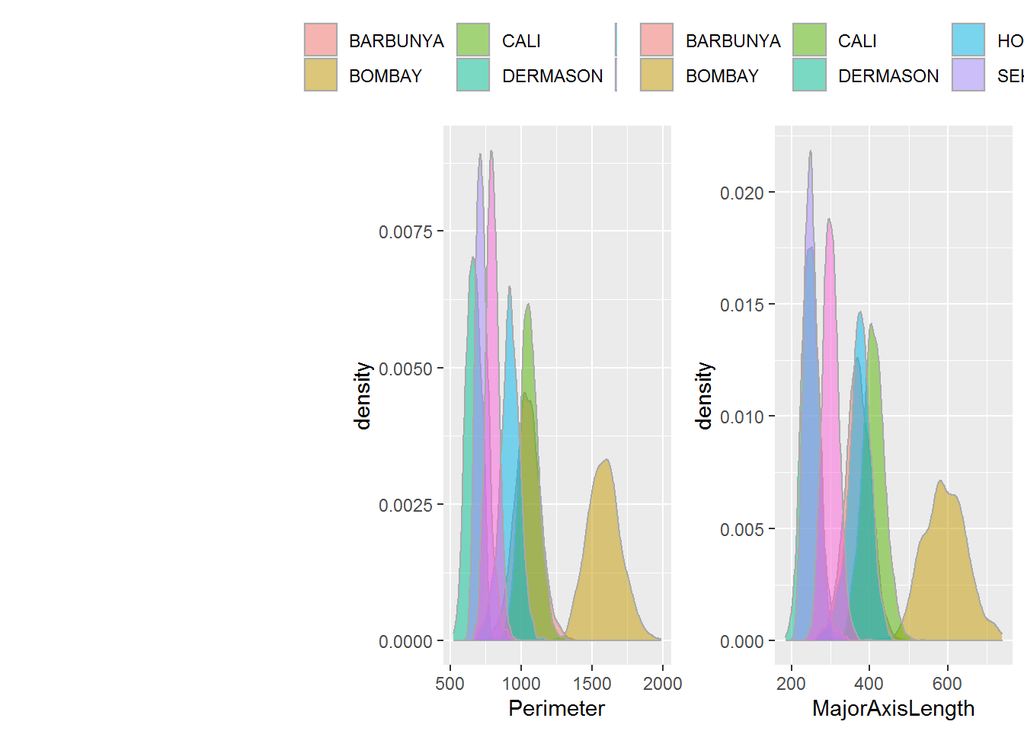

```r
p = list()
for(i in 2:3){
p[[i]] = ggplot(dados, aes_string(x=names(dados)[i],fill="Class")) +
geom_density(alpha=0.5,color="darkgray") +
theme(legend.position="top", legend.title = element_blank())
}
do.call(grid.arrange,c(p,ncol=3))
```

## Na variavel Área a classe Bombay possui densidade inferior em relação as outras classes

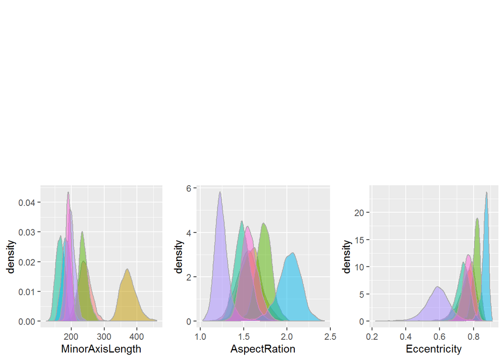

```r
p = list()
for(i in 4:6){
p[[i]] = ggplot(dados, aes_string(x=names(dados)[i],fill="Class")) +
geom_density(alpha=0.5,color="darkgray") +
theme(legend.position="", legend.title = element_blank())
}
do.call(grid.arrange,c(p,ncol=3))
```

## Na variavel Perimeter a classe Bombay possui densidade inferior em relação as outras classes

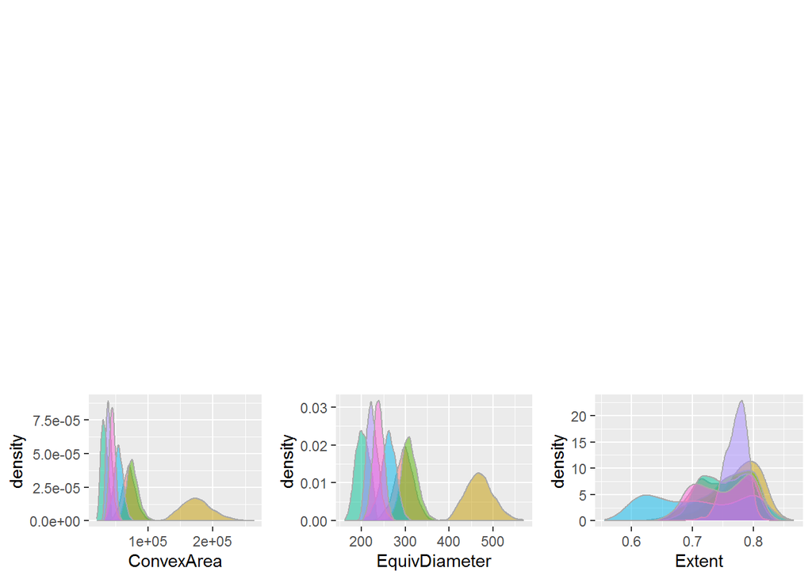

```r
p = list()
for(i in 7:9){
p[[i]] = ggplot(dados, aes_string(x=names(dados)[i],fill="Class")) +
geom_density(alpha=0.5,color="darkgray") +
theme(legend.position="", legend.title = element_blank())
}
do.call(grid.arrange,c(p,ncol=3))
```

## Na variavel MajorAxisLength a classe Bombay possui densidade inferior em relação as outras classes e Seker superior a todas as classes

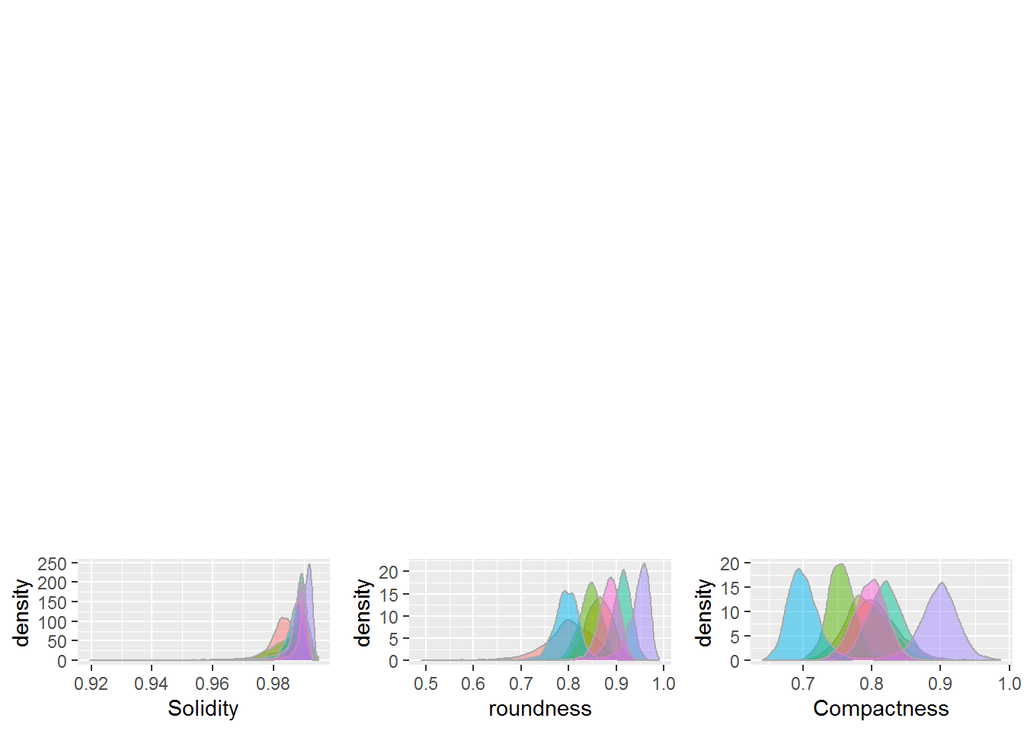

```r
p = list()
for(i in 10:12){
p[[i]] = ggplot(dados, aes_string(x=names(dados)[i],fill="Class")) +
geom_density(alpha=0.5,color="darkgray") +
theme(legend.position="", legend.title = element_blank())
}
do.call(grid.arrange,c(p,ncol=3))
```

## Na variavel MinorAxisLength a classe Sira possui densidade superior em relação as outras classes

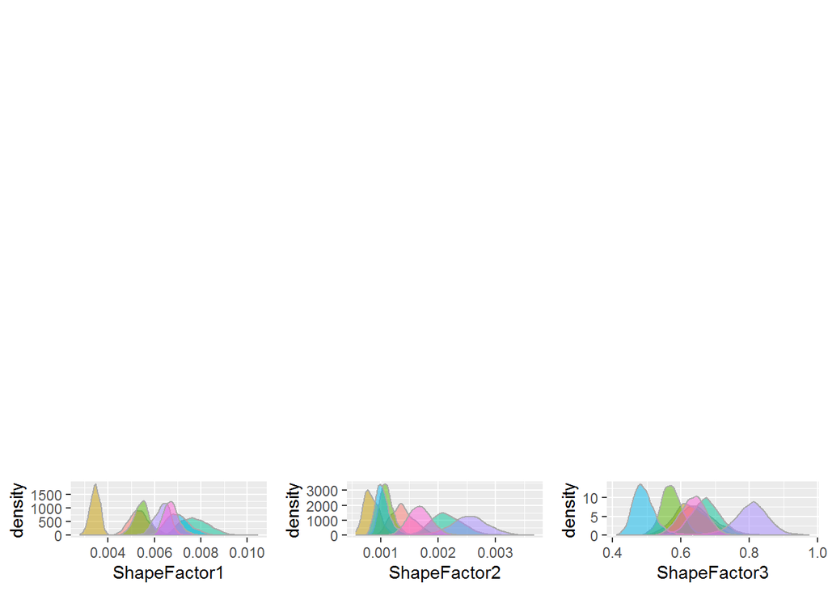

```r
p = list()
for(i in 13:15){
p[[i]] = ggplot(dados, aes_string(x=names(dados)[i],fill="Class")) +
geom_density(alpha=0.5,color="darkgray") +
theme(legend.position="", legend.title = element_blank())
}
do.call(grid.arrange,c(p,ncol=3))
```

## Na variavel AspectRation a classe Seker possui densidade superior em relação as outras classes

## Na variavel Eccentricity a classe Seker possui densidade inferior em relação as outras classes e horroz superior

## Na variavel ConvexÁrea a classe Bombay possui densidade inferior em relação as outras classes

## Na variavel EquivDiameter a classe Bombay possui densidade inferior em relação as outras classes

## Na variavel Extent a classe Seker possui densidade superior em relação as outras classes

## Na variavel Solidity a classe Barbunya possui densidade inferior em relação as outras classes e Seker superior

## Na variavel roundness a classe Seker possui densidade superior em relação as outras classes

## Na variavel ShapeFactor1 a classe Bombay possui densidade superior em relação as outras classes

## Na variavel ShapeFactor2 a classe Bombay possui densidade diferente em relação as outras classes

## Na variavel ShapeFactor3 a classe Seker possui densidade diferente em relação as outras classes

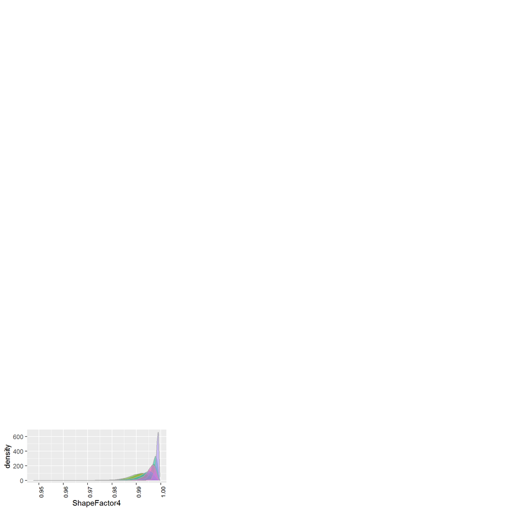

```r
p = list()
for(i in 16:16){
p[[i]] =  ggplot(dados, aes_string(x=names(dados)[i],fill="Class")) +
geom_density(alpha=0.5,color="darkgray") +
  theme(axis.text.x = element_text(angle = 90, colour = "black", size = 8),legend.position="",legend.direction = "horizontal", legend.title = element_blank())

}
do.call(grid.arrange,c(p,ncol=3))
```

## Na variavel ShapeFactor4 a classe Seker possui densidade superior em relação as outras classes

# 7.Algumas variável (por classe) possui uma distribuição normal (curva do sino)? É possível verificar numericamente se é verdade?

### Seker

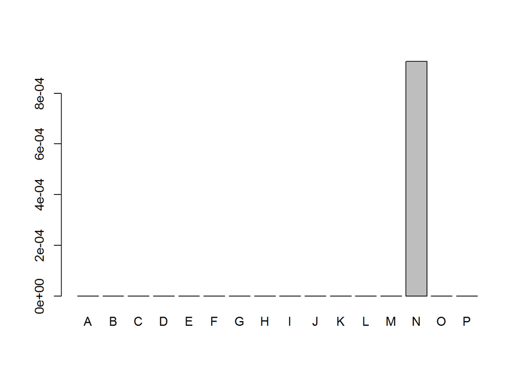

```r
name=c("A","B","C","D","E","F","G","H","I","J","K","L","M","N","O","P")
pvalue = c()
for(i in 1:16){
pvalue[i] = shapiro.test(dados[dados$Class=="SEKER",i])$p.value
}
barplot(pvalue,names.arg = name)
abline(h=0.05, col = "Red", lty = 5, lwd = 2)
```

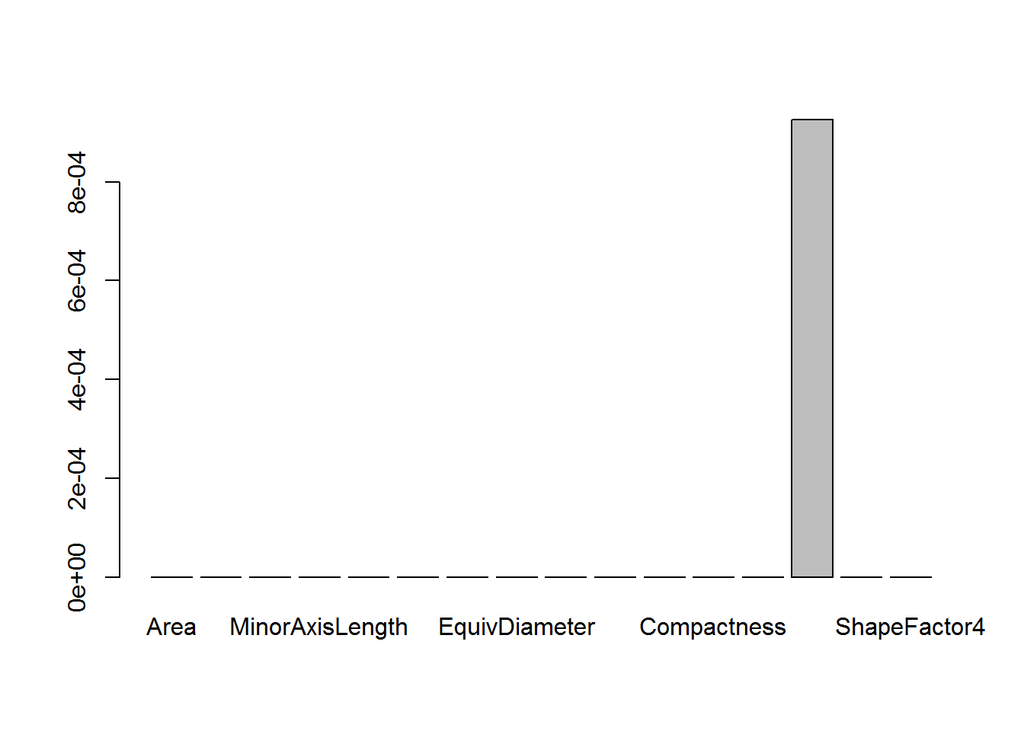

```r
 pvalue = c()
for(i in 1:16){
pvalue[i] = shapiro.test(dados[dados$Class=="SEKER",i])$p.value
}
barplot(pvalue,names.arg = names(dados)[1:16])
abline(h=0.05, col = "Red", lty = 5, lwd = 2)
```

### SIRA

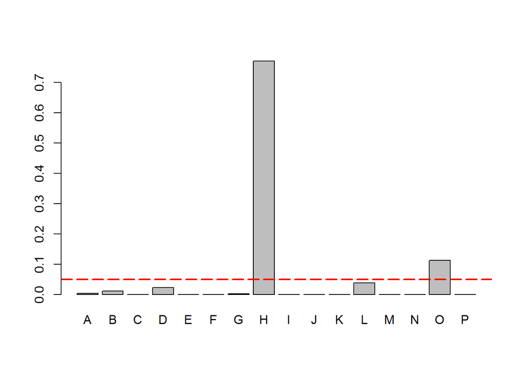

```r
name=c("A","B","C","D","E","F","G","H","I","J","K","L","M","N","O","P")
pvalue = c()
for(i in 1:16){
pvalue[i] = shapiro.test(dados[dados$Class=="SIRA",i])$p.value
}
barplot(pvalue,names.arg = name)
abline(h=0.05, col = "Red", lty = 5, lwd = 2)
```

### ShapeFactor3 e EquivDiameter possuem distribuições normais

### HOROZ

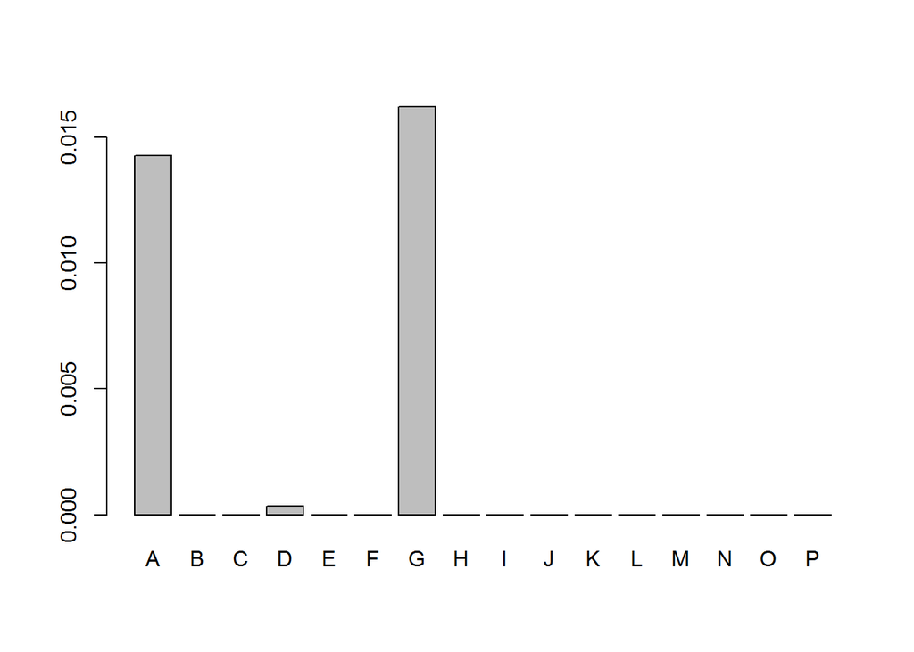

```r
name=c("A","B","C","D","E","F","G","H","I","J","K","L","M","N","O","P")
pvalue = c()
for(i in 1:16){
pvalue[i] = shapiro.test(dados[dados$Class=="HOROZ",i])$p.value
}
barplot(pvalue,names.arg = name)
abline(h=0.05, col = "Red", lty = 5, lwd = 2)
```